# Final Assignment Part II : Ecommerce Data Set

```python
import pandas as pd
import datetime as dt
import numpy as np

import matplotlib.pyplot as plt

import warnings
warnings.filterwarnings("ignore")

from scipy import stats
%matplotlib inline
import seaborn as sns
import squarify
```

## Read Data

```python
ecom = pd.read_excel('Final Assignment - Week 9.xlsx')
ecom.head(5)
```

|  | id | logtarg | r | f | m | tof | Ffiction1 | Fclassics3 | Fcartoons5 | Flegends6 | ... | MGamesRiddles38 | Msports39 | Mhobby40 | Mnature41 | Mencyclopaedia44 | Mvideos50 | Mnonbooks99 | Unnamed: 66 | Unnamed: 67 | Dear Greg, |
| --- | --- | --- | --- | --- | --- | --- | --- | --- | --- | --- | --- | --- | --- | --- | --- | --- | --- | --- | --- | --- | --- |
| 0 | 914 | NaN | 194 | 7 | 318.894775 | 1703 | 1 | 0 | 1 | 0 | ... | 0.0 | 0.0 | 0.000000 | 0.000000 | 0.0 | 0.000000 | 0.0 | NaN | NaN | NaN |
| 1 | 957 | NaN | 3 | 14 | 368.052246 | 2364 | 1 | 0 | 2 | 0 | ... | 0.0 | 0.0 | 61.176025 | 17.150269 | 10.0 | 0.000000 | 0.0 | NaN | NaN | I wanted to find something that the students c... |
| 2 | 1406 | NaN | 1489 | 15 | 423.298340 | 2371 | 0 | 0 | 0 | 0 | ... | 0.0 | 0.0 | 0.000000 | 0.000000 | 0.0 | 0.000000 | 0.0 | NaN | NaN | NaN |
| 3 | 1414 | NaN | 155 | 4 | 71.217041 | 1290 | 0 | 0 | 0 | 0 | ... | 0.0 | 0.0 | 0.000000 | 0.000000 | 0.0 | 0.000000 | 0.0 | NaN | NaN | I have data from American Science and Surplus,... |
| 4 | 1546 | NaN | 194 | 6 | 442.638184 | 2188 | 0 | 0 | 1 | 0 | ... | 0.0 | 0.0 | 17.895203 | 0.000000 | 0.0 | 61.799988 | 0.0 | NaN | NaN | NaN |

5 rows × 69 columns

```python
ecom.shape
```

```
(33713, 69)
```

#### 1. Perform descriptive statistics on all variables to help understand the data, the distributions and basic info you have to work with on this challenge. (Mean, Standard Deviation, Median, Min, Max and Histogram)

```python
ecom.describe()
```

|  | id | logtarg | r | f | m | tof | Ffiction1 | Fclassics3 | Fcartoons5 | Flegends6 | ... | Mlearning37 | MGamesRiddles38 | Msports39 | Mhobby40 | Mnature41 | Mencyclopaedia44 | Mvideos50 | Mnonbooks99 | Unnamed: 66 | Unnamed: 67 |
| --- | --- | --- | --- | --- | --- | --- | --- | --- | --- | --- | --- | --- | --- | --- | --- | --- | --- | --- | --- | --- | --- |
| count | 3.371300e+04 | 8311.000000 | 33713.000000 | 33713.000000 | 33713.000000 | 33713.000000 | 33713.000000 | 33713.000000 | 33713.000000 | 33713.000000 | ... | 33713.000000 | 33713.000000 | 33713.000000 | 33713.000000 | 33713.000000 | 33713.000000 | 33713.000000 | 33713.000000 | 0.0 | 0.0 |
| mean | 8.234209e+06 | 0.130050 | 508.427254 | 5.820603 | 251.924325 | 1296.088186 | 0.590900 | 0.228102 | 0.356480 | 0.104767 | ... | 21.147507 | 0.305226 | 0.020681 | 6.785558 | 3.728635 | 8.402428 | 6.020431 | 1.800973 | NaN | NaN |
| std | 4.426015e+06 | 0.659962 | 542.440039 | 7.008049 | 3929.929826 | 818.976321 | 1.762201 | 0.865510 | 1.105653 | 0.527764 | ... | 2898.452008 | 1.991675 | 0.501499 | 21.197488 | 15.007592 | 46.021881 | 19.643978 | 21.383867 | NaN | NaN |
| min | 9.140000e+02 | 0.000000 | 0.000000 | 0.000000 | 0.000000 | 0.000000 | 0.000000 | 0.000000 | 0.000000 | 0.000000 | ... | 0.000000 | 0.000000 | 0.000000 | 0.000000 | 0.000000 | 0.000000 | 0.000000 | 0.000000 | NaN | NaN |
| 25% | 4.391616e+06 | 0.000000 | 117.000000 | 1.000000 | 39.899994 | 536.000000 | 0.000000 | 0.000000 | 0.000000 | 0.000000 | ... | 0.000000 | 0.000000 | 0.000000 | 0.000000 | 0.000000 | 0.000000 | 0.000000 | 0.000000 | NaN | NaN |
| 50% | 7.967691e+06 | 0.000000 | 293.000000 | 3.000000 | 102.629944 | 1311.000000 | 0.000000 | 0.000000 | 0.000000 | 0.000000 | ... | 0.000000 | 0.000000 | 0.000000 | 0.000000 | 0.000000 | 0.000000 | 0.000000 | 0.000000 | NaN | NaN |
| 75% | 1.199823e+07 | 0.000000 | 712.000000 | 7.000000 | 247.297485 | 2132.000000 | 1.000000 | 0.000000 | 0.000000 | 0.000000 | ... | 2.500000 | 0.000000 | 0.000000 | 5.112919 | 0.000000 | 0.000000 | 0.000000 | 0.000000 | NaN | NaN |
| max | 1.625264e+07 | 6.082878 | 2460.000000 | 118.000000 | 532892.000000 | 2462.000000 | 109.000000 | 29.000000 | 49.000000 | 22.000000 | ... | 532182.000000 | 78.724670 | 21.448685 | 771.610840 | 735.354980 | 1999.150391 | 794.137695 | 2412.960938 | NaN | NaN |

8 rows × 68 columns

## Data Pre-Processing

```python
def missing_perc(df):
    """
    Function to calculate missing data % by column
    given a data frame

    """
    missing_df = pd.DataFrame()
    missing_df['Col Name'] = list(df.columns)
    missing_df['Missing %'] = [round(i/df.shape[0] * 100,2) for i in df.isnull().sum()]
    missing_df.sort_values(by=['Missing %'], ascending=False,inplace=True)
    missing_df['Missing %'] = missing_df['Missing %'].astype('str') + '%'
    pd.set_option('display.max_rows', None)
    return missing_df
# Calculate missing data % per column
missing_perc(ecom)
```

|  | Col Name | Missing % |
| --- | --- | --- |
| 66 | Unnamed: 66 | 100.0% |
| 67 | Unnamed: 67 | 100.0% |
| 68 | Dear Greg, | 99.99% |
| 1 | logtarg | 75.35% |
| 65 | Mnonbooks99 | 0.0% |
| 49 | Meconomy21 | 0.0% |
| 36 | Mfiction1 | 0.0% |
| 37 | Mclassics3 | 0.0% |
| 38 | Mcartoons5 | 0.0% |
| 39 | Mlegends6 | 0.0% |
| 40 | Mphilosophy7 | 0.0% |
| 41 | Mreligion8 | 0.0% |
| 42 | Mpsychology9 | 0.0% |
| 43 | Mlinguistics10 | 0.0% |
| 44 | Mart12 | 0.0% |
| 45 | Mmusic14 | 0.0% |
| 46 | Mfacsimile17 | 0.0% |
| 47 | Mhistory19 | 0.0% |
| 48 | Mconthist20 | 0.0% |
| 50 | Mpolitics22 | 0.0% |
| 64 | Mvideos50 | 0.0% |
| 51 | Mscience23 | 0.0% |
| 35 | Fnonbooks99 | 0.0% |
| 53 | Mrailroads27 | 0.0% |
| 54 | Mmaps30 | 0.0% |
| 55 | Mtravelguides31 | 0.0% |
| 56 | Mhealth35 | 0.0% |
| 57 | Mcooking36 | 0.0% |
| 58 | Mlearning37 | 0.0% |
| 59 | MGamesRiddles38 | 0.0% |
| 60 | Msports39 | 0.0% |
| 61 | Mhobby40 | 0.0% |
| 62 | Mnature41 | 0.0% |
| 63 | Mencyclopaedia44 | 0.0% |
| 52 | Mcompsci26 | 0.0% |
| 0 | id | 0.0% |
| 33 | Fencyclopaedia44 | 0.0% |
| 16 | Ffacsimile17 | 0.0% |
| 2 | r | 0.0% |
| 3 | f | 0.0% |
| 4 | m | 0.0% |
| 5 | tof | 0.0% |
| 6 | Ffiction1 | 0.0% |
| 7 | Fclassics3 | 0.0% |
| 8 | Fcartoons5 | 0.0% |
| 9 | Flegends6 | 0.0% |
| 10 | Fphilosophy7 | 0.0% |
| 11 | Freligion8 | 0.0% |
| 12 | Fpsychology9 | 0.0% |
| 13 | Flinguistics10 | 0.0% |
| 14 | Fart12 | 0.0% |
| 15 | Fmusic14 | 0.0% |
| 17 | Fhistory19 | 0.0% |
| 32 | Fnature41 | 0.0% |
| 18 | Fconthist20 | 0.0% |
| 19 | Feconomy21 | 0.0% |
| 20 | Fpolitics22 | 0.0% |
| 21 | Fscience23 | 0.0% |
| 22 | Fcompsci26 | 0.0% |
| 23 | Frailroads27 | 0.0% |
| 24 | Fmaps30 | 0.0% |
| 25 | Ftravelguides31 | 0.0% |
| 26 | Fhealth35 | 0.0% |
| 27 | Fcooking36 | 0.0% |
| 28 | Flearning37 | 0.0% |
| 29 | FGamesRiddles38 | 0.0% |
| 30 | Fsports39 | 0.0% |
| 31 | Fhobby40 | 0.0% |
| 34 | Fvideos50 | 0.0% |

```python
ecom.isnull().sum()
```

```
id                      0
logtarg             25402
r                       0
f                       0
m                       0
tof                     0
Ffiction1               0
Fclassics3              0
Fcartoons5              0
Flegends6               0
Fphilosophy7            0
Freligion8              0
Fpsychology9            0
Flinguistics10          0
Fart12                  0
Fmusic14                0
Ffacsimile17            0
Fhistory19              0
Fconthist20             0
Feconomy21              0
Fpolitics22             0
Fscience23              0
Fcompsci26              0
Frailroads27            0
Fmaps30                 0
Ftravelguides31         0
Fhealth35               0
Fcooking36              0
Flearning37             0
FGamesRiddles38         0
Fsports39               0
Fhobby40                0
Fnature41               0
Fencyclopaedia44        0
Fvideos50               0
Fnonbooks99             0
Mfiction1               0
Mclassics3              0
Mcartoons5              0
Mlegends6               0
```

[output cut: 15 more lines]

```
Mtravelguides31         0
Mhealth35               0
Mcooking36              0
Mlearning37             0
MGamesRiddles38         0
Msports39               0
Mhobby40                0
Mnature41               0
Mencyclopaedia44        0
Mvideos50               0
Mnonbooks99             0
Unnamed: 66         33713
Unnamed: 67         33713
Dear Greg,          33709
dtype: int64
```

```python
ecom[ecom['logtarg'].notnull() & ecom['logtarg']!=0.000000].head()
```

|  | id | logtarg | r | f | m | tof | Ffiction1 | Fclassics3 | Fcartoons5 | Flegends6 | ... | MGamesRiddles38 | Msports39 | Mhobby40 | Mnature41 | Mencyclopaedia44 | Mvideos50 | Mnonbooks99 | Unnamed: 66 | Unnamed: 67 | Dear Greg, |
| --- | --- | --- | --- | --- | --- | --- | --- | --- | --- | --- | --- | --- | --- | --- | --- | --- | --- | --- | --- | --- | --- |
| 25417 | 11282 | 3.362108 | 1418 | 2 | 27.942093 | 1803 | 0 | 0 | 0 | 0 | ... | 0.0 | 0.0 | 0.000000 | 0.0 | 0.000000 | 22.88031 | 0.0 | NaN | NaN | NaN |
| 25430 | 23205 | 3.034952 | 1168 | 9 | 205.692627 | 2454 | 4 | 0 | 0 | 0 | ... | 0.0 | 0.0 | 27.021759 | 0.0 | 6.135502 | 0.00000 | 0.0 | NaN | NaN | NaN |
| 25469 | 58521 | 3.131136 | 300 | 10 | 290.548096 | 2358 | 2 | 1 | 1 | 0 | ... | 0.0 | 0.0 | 0.000000 | 0.0 | 0.000000 | 0.00000 | 0.0 | NaN | NaN | NaN |
| 25470 | 58807 | 2.191652 | 34 | 34 | 486.390381 | 2460 | 1 | 0 | 0 | 0 | ... | 0.0 | 0.0 | 0.000000 | 0.0 | 0.000000 | 0.00000 | 0.0 | NaN | NaN | NaN |
| 25486 | 69094 | 3.131136 | 264 | 15 | 319.446533 | 2377 | 0 | 0 | 0 | 0 | ... | 0.0 | 0.0 | 15.338753 | 0.0 | 20.349411 | 0.00000 | 0.0 | NaN | NaN | NaN |

5 rows × 69 columns

#### 2. Create a new data set with more descriptive labels and the data needed for analysis

```python
ecom = ecom.drop(['logtarg','Unnamed: 66','Unnamed: 67', 'Dear Greg,'], axis = 1)
ecom.head(5)
```

|  | id | r | f | m | tof | Ffiction1 | Fclassics3 | Fcartoons5 | Flegends6 | Fphilosophy7 | ... | Mhealth35 | Mcooking36 | Mlearning37 | MGamesRiddles38 | Msports39 | Mhobby40 | Mnature41 | Mencyclopaedia44 | Mvideos50 | Mnonbooks99 |
| --- | --- | --- | --- | --- | --- | --- | --- | --- | --- | --- | --- | --- | --- | --- | --- | --- | --- | --- | --- | --- | --- |
| 0 | 914 | 194 | 7 | 318.894775 | 1703 | 1 | 0 | 1 | 0 | 0 | ... | 14.899994 | 10.174706 | 0.000000 | 0.0 | 0.0 | 0.000000 | 0.000000 | 0.0 | 0.000000 | 0.0 |
| 1 | 957 | 3 | 14 | 368.052246 | 2364 | 1 | 0 | 2 | 0 | 0 | ... | 74.156250 | 0.000000 | 22.749985 | 0.0 | 0.0 | 61.176025 | 17.150269 | 10.0 | 0.000000 | 0.0 |
| 2 | 1406 | 1489 | 15 | 423.298340 | 2371 | 0 | 0 | 0 | 0 | 0 | ... | 0.000000 | 0.000000 | 0.000000 | 0.0 | 0.0 | 0.000000 | 0.000000 | 0.0 | 0.000000 | 0.0 |
| 3 | 1414 | 155 | 4 | 71.217041 | 1290 | 0 | 0 | 0 | 0 | 0 | ... | 0.000000 | 0.000000 | 0.000000 | 0.0 | 0.0 | 0.000000 | 0.000000 | 0.0 | 0.000000 | 0.0 |
| 4 | 1546 | 194 | 6 | 442.638184 | 2188 | 0 | 0 | 1 | 0 | 3 | ... | 41.518219 | 0.000000 | 7.949997 | 0.0 | 0.0 | 17.895203 | 0.000000 | 0.0 | 61.799988 | 0.0 |

5 rows × 65 columns

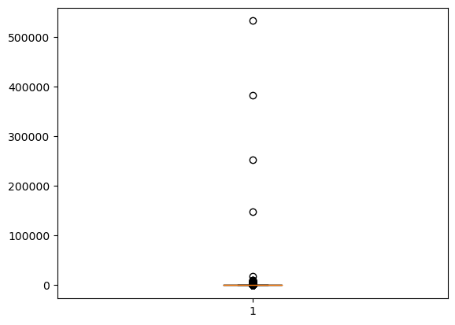

```python
plt.boxplot(ecom['m'])
pass
```

```python
## Remove outliers
def remove_outliers(df, columns):
    int_df = df
    for x in int_df[columns]:
        int_df = int_df[int_df[x] < df[x].quantile(0.99)]
    return int_df
```

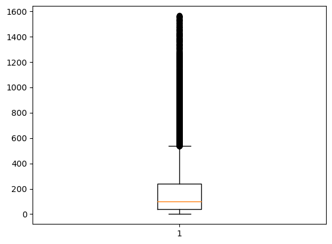

```python
ecom = remove_outliers(ecom, ['r','f','m'])
plt.boxplot(ecom['m'])
pass
```

```python
ecom.isnull().sum()
```

```
id                  0
r                   0
f                   0
m                   0
tof                 0
Ffiction1           0
Fclassics3          0
Fcartoons5          0
Flegends6           0
Fphilosophy7        0
Freligion8          0
Fpsychology9        0
Flinguistics10      0
Fart12              0
Fmusic14            0
Ffacsimile17        0
Fhistory19          0
Fconthist20         0
Feconomy21          0
Fpolitics22         0
Fscience23          0
Fcompsci26          0
Frailroads27        0
Fmaps30             0
Ftravelguides31     0
Fhealth35           0
Fcooking36          0
Flearning37         0
FGamesRiddles38     0
Fsports39           0
Fhobby40            0
Fnature41           0
Fencyclopaedia44    0
Fvideos50           0
Fnonbooks99         0
Mfiction1           0
Mclassics3          0
Mcartoons5          0
Mlegends6           0
Mphilosophy7        0
```

[output cut: 11 more lines]

```
Mcompsci26          0
Mrailroads27        0
Mmaps30             0
Mtravelguides31     0
Mhealth35           0
Mcooking36          0
Mlearning37         0
MGamesRiddles38     0
Msports39           0
Mhobby40            0
Mnature41           0
Mencyclopaedia44    0
Mvideos50           0
Mnonbooks99         0
dtype: int64
```

```python
ecom.dtypes
```

```
id                    int64
r                     int64
f                     int64
m                   float64
tof                   int64
Ffiction1             int64
Fclassics3            int64
Fcartoons5            int64
Flegends6             int64
Fphilosophy7          int64
Freligion8            int64
Fpsychology9          int64
Flinguistics10        int64
Fart12                int64
Fmusic14              int64
Ffacsimile17          int64
Fhistory19            int64
Fconthist20           int64
Feconomy21            int64
Fpolitics22           int64
Fscience23            int64
Fcompsci26            int64
Frailroads27          int64
Fmaps30               int64
Ftravelguides31       int64
Fhealth35             int64
Fcooking36            int64
Flearning37           int64
FGamesRiddles38       int64
Fsports39             int64
Fhobby40              int64
Fnature41             int64
Fencyclopaedia44      int64
Fvideos50             int64
Fnonbooks99           int64
Mfiction1           float64
Mclassics3          float64
Mcartoons5          float64
Mlegends6           float64
Mphilosophy7        float64
```

[output cut: 11 more lines]

```
Mcompsci26          float64
Mrailroads27        float64
Mmaps30             float64
Mtravelguides31     float64
Mhealth35           float64
Mcooking36          float64
Mlearning37         float64
MGamesRiddles38     float64
Msports39           float64
Mhobby40            float64
Mnature41           float64
Mencyclopaedia44    float64
Mvideos50           float64
Mnonbooks99         float64
dtype: object
```

```python
ecom.shape
```

```
(32831, 65)
```

```python
ecom.columns = [c.replace("F", "Count_") for c in list(ecom.columns)]
ecom.columns = [c.replace("M", "Sales_") for c in list(ecom.columns)]
ecom.columns = ecom.columns.str.replace('\d+', '')
ecom = ecom.rename(columns = {'r' : 'Recency','f' : 'Frequency', 'm' : 'Monetary', 'tof' : 'Time on File'})
ecom.columns
```

```
Index(['id', 'Recency', 'Frequency', 'Monetary', 'Time on File',
       'Count_fiction', 'Count_classics', 'Count_cartoons', 'Count_legends',
       'Count_philosophy', 'Count_religion', 'Count_psychology',
       'Count_linguistics', 'Count_art', 'Count_music', 'Count_facsimile',
       'Count_history', 'Count_conthist', 'Count_economy', 'Count_politics',
       'Count_science', 'Count_compsci', 'Count_railroads', 'Count_maps',
       'Count_travelguides', 'Count_health', 'Count_cooking', 'Count_learning',
       'Count_GamesRiddles', 'Count_sports', 'Count_hobby', 'Count_nature',
       'Count_encyclopaedia', 'Count_videos', 'Count_nonbooks',
       'Sales_fiction', 'Sales_classics', 'Sales_cartoons', 'Sales_legends',
       'Sales_philosophy', 'Sales_religion', 'Sales_psychology',
       'Sales_linguistics', 'Sales_art', 'Sales_music', 'Sales_facsimile',
       'Sales_history', 'Sales_conthist', 'Sales_economy', 'Sales_politics',
       'Sales_science', 'Sales_compsci', 'Sales_railroads', 'Sales_maps',
       'Sales_travelguides', 'Sales_health', 'Sales_cooking', 'Sales_learning',
       'Sales_GamesRiddles', 'Sales_sports', 'Sales_hobby', 'Sales_nature',
       'Sales_encyclopaedia', 'Sales_videos', 'Sales_nonbooks'],
      dtype='object')
```

```python
#Check
ecom_new = ecom
col_list = [col for col in ecom_new if col.startswith('Count_')]
ecom_new['F'] = ecom_new.loc[:,col_list].sum(axis = 1)
col_list = [col for col in ecom_new if col.startswith('Sales_')]
ecom_new['M'] = ecom_new.loc[:,col_list].sum(axis = 1)
print(ecom_new.head(5))
ecom_new = ecom_new.drop(['F', 'M'], axis = 1)
```

```
     id  Recency  Frequency    Monetary  Time on File  Count_fiction  \
0   914      194          7  318.894775          1703              1
1   957        3         14  368.052246          2364              1
2  1406     1489         15  423.298340          2371              0
3  1414      155          4   71.217041          1290              0
4  1546      194          6  442.638184          2188              0

   Count_classics  Count_cartoons  Count_legends  Count_philosophy  ...  \
0               0               1              0                 0  ...
1               0               2              0                 0  ...
2               0               0              0                 0  ...
3               0               0              0                 0  ...
4               0               1              0                 3  ...

   Sales_learning  Sales_GamesRiddles  Sales_sports  Sales_hobby  \
```

[output cut: 21 more lines]

As mentioned by Professor, the Frequency need not be recalculated.

#### Creating a Transactional Data Set to do EDA across categories

```python
#col_list = [col for col in ecom if col.startswith('Sales_')]
#ecom_check = ecom.loc[:, ~ecom.columns.isin(['Recency', 'Frequency', 'Monetary', 'Time on File'])]
#ecom_check = ecom_check.loc[:, ~ecom_check.columns.isin(col_list)]
ecom_check = ecom
col_list = [col for col in ecom_check if col.startswith('Count_')]
ecom_check = ecom_check.melt(id_vars=['id', 'Recency', 'Frequency', 'Monetary', 'Time on File'], var_name='Category', value_vars=col_list, value_name='Count')

#ecom_check2 = ecom.loc[:, ~ecom.columns.isin(['Recency', 'Frequency', 'Monetary', 'Time on File'])]
ecom_check2 = ecom
col_list = [col for col in ecom_check2 if col.startswith('Sales_')]
ecom_check2 = ecom_check2.melt(id_vars=['id', 'Recency', 'Frequency', 'Monetary', 'Time on File'], var_name='Category_2', value_vars=col_list, value_name='Sales')

ecom_customer = pd.concat([ecom_check, ecom_check2.loc[:, ~ecom_check2.columns.isin(['id', 'Recency', 'Frequency', 'Monetary', 'Time on File'])]], axis=1)
ecom_customer = ecom_customer.drop(['Category_2'], axis = 1)
ecom_customer[ecom_customer['id'] == 914].head()
```

|  | id | Recency | Frequency | Monetary | Time on File | Category | Count | Sales |
| --- | --- | --- | --- | --- | --- | --- | --- | --- |
| 0 | 914 | 194 | 7 | 318.894775 | 1703 | Count_fiction | 1 | 5.949997 |
| 32831 | 914 | 194 | 7 | 318.894775 | 1703 | Count_classics | 0 | 0.000000 |
| 65662 | 914 | 194 | 7 | 318.894775 | 1703 | Count_cartoons | 1 | 7.643810 |
| 98493 | 914 | 194 | 7 | 318.894775 | 1703 | Count_legends | 0 | 0.000000 |
| 131324 | 914 | 194 | 7 | 318.894775 | 1703 | Count_philosophy | 0 | 0.000000 |

#### Found categories with monetaryvalue 0, we can assume it is free book

```python
ecom_customer['Category'] = ecom_customer['Category'].str.replace('Count_', '')
ecom_customer = ecom_customer[(ecom_customer['Count'] != 0)]
ecom_customer[(ecom_customer['Sales'] == 0)].head()
```

|  | id | Recency | Frequency | Monetary | Time on File | Category | Count | Sales |
| --- | --- | --- | --- | --- | --- | --- | --- | --- |
| 8 | 2801 | 96 | 9 | 164.324341 | 2453 | fiction | 1 | 0.0 |
| 40 | 18830 | 82 | 4 | 75.278870 | 634 | fiction | 1 | 0.0 |
| 135 | 50130 | 620 | 6 | 159.306763 | 2078 | fiction | 1 | 0.0 |
| 248 | 83070 | 3 | 7 | 249.074097 | 2363 | fiction | 1 | 0.0 |
| 265 | 88897 | 618 | 2 | 85.230408 | 2435 | fiction | 1 | 0.0 |

```python
ecom_analysis = ecom_customer
ecom_group= ecom_analysis.groupby(by=['Category']).sum()
ecom_group = ecom_group.reset_index(level=0)
ecom_group.head()
```

|  | Category | id | Recency | Frequency | Monetary | Time on File | Count | Sales |
| --- | --- | --- | --- | --- | --- | --- | --- | --- |
| 0 | GamesRiddles | 7038295421 | 316570 | 8402 | 3.299649e+05 | 1419878 | 1032 | 9128.884351 |
| 1 | art | 54837767668 | 3828560 | 74939 | 2.941457e+06 | 14193270 | 17131 | 302451.684589 |
| 2 | cartoons | 45260555318 | 2315667 | 55303 | 2.033638e+06 | 9558944 | 10484 | 72614.871039 |
| 3 | classics | 24281955115 | 1879359 | 40239 | 1.605018e+06 | 7199358 | 6441 | 108179.792366 |
| 4 | compsci | 19026448264 | 1365995 | 29565 | 1.125416e+06 | 5314950 | 4546 | 39891.695922 |

## Exploratory Data Analysis

What are the categories?

```python
ecom_group['Category']
```

```
0      GamesRiddles
1               art
2          cartoons
3          classics
4           compsci
5          conthist
6           cooking
7           economy
8     encyclopaedia
9         facsimile
10          fiction
11           health
12          history
13            hobby
14         learning
```

[output cut: 16 more lines]

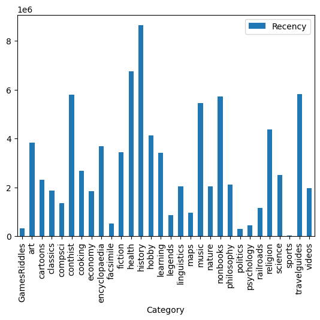

```python
ecom_group.plot.bar(x='Category', y='Recency')
pass
```

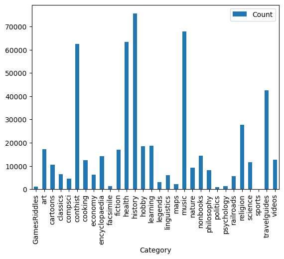

```python
ecom_group.plot.bar(x='Category', y='Count')
pass
```

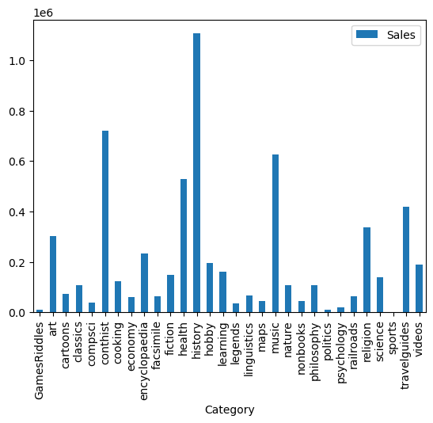

```python
ecom_group.plot.bar(x='Category', y='Sales')
pass
```

Dataset without outliers

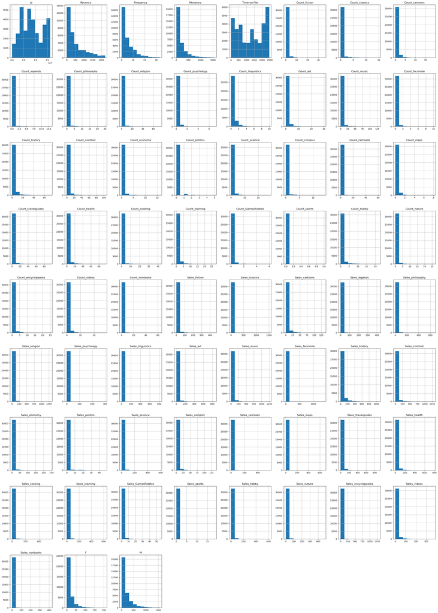

```python
fig = plt.figure(figsize=(35,50))
ax = fig.gca()
ecom.hist(ax=ax)
pass
```

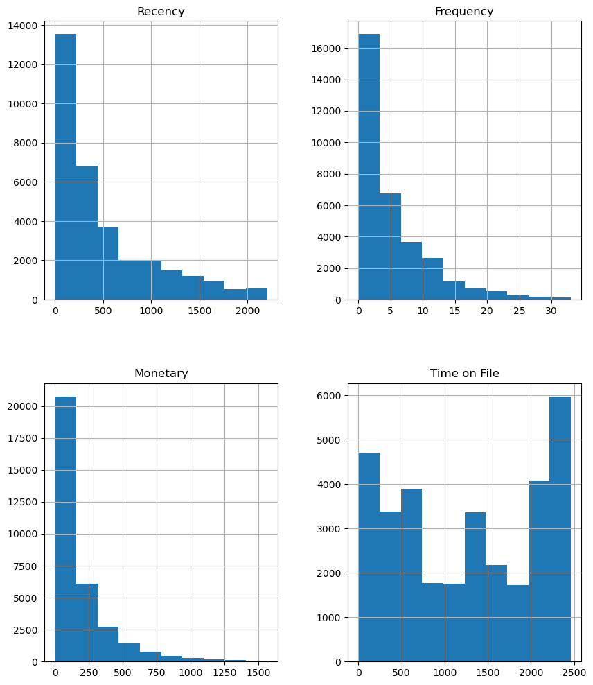

```python
ecom_rfm = ecom[['Recency','Frequency','Monetary','Time on File']]
ecom_rfm.hist(figsize=(10,12))
pass
```

## Using RFM Model to perform customer segmentation

Most customers can be put into 3 buckets, 1: Very Recent, 2: Average, but should be nudged 3: Requires Activation

```python
r_label = range(1,4)
r = pd.qcut(ecom['Recency'], q=[0,.1,.5,1], labels=r_label,retbins=True)
r_group = r[0]
r_bins = r[1]
ecom_process = ecom.assign(R = r_group.values)
print(r_group.head(10), r_bins)
```

```
0    2
1    1
2    3
3    2
4    2
5    3
6    3
7    2
8    2
9    3
Name: Recency, dtype: category
Categories (3, int64): [1 < 2 < 3] [   0.   33.  293. 2204.]
```

Most customers can be put into 4 buckets, 1: New Customer, 2: Average Customer, 3: Potentially Loyal, 4: Loyal Customer

```python
f_labels = range(1, 5)
f = pd.qcut(ecom['Frequency'], q=[0,.1,0.5,.9,1], labels=f_labels,retbins=True)
f_group = f[0]
f_bins = f[1]
ecom_process = ecom_process.assign(F = f_group.values)
```

Monetary has been split into only 3 categories. While it is usefull to identify big spenders, the average spender does not need more than 1 category to represent it. The vast amount of customers can be split into .2% to .8%, while big spenders are greater than.8%

```python
m_labels = range(1, 4)
m = pd.qcut(ecom['Monetary'], q=[0,.2,.8,1], labels=m_labels,retbins=True)
m_group = m[0]
m_bins = m[1]
ecom_process = ecom_process.assign(M = m_group.values)
ecom_process.head()
print(m_group)
```

```
0        3
1        3
2        3
3        2
4        3
5        2
6        2
7        2
8        2
9        2
10       2
11       3
12       3
13       3
14       2
```

[output cut: 32818 more lines]

```python
# Concat RFM quartile values to create RFM Segments
def join_rfm(x): return str(int(x['R'])) + str(int(x['F'])) + str(int(x['M']))
ecom_process['RFM_Segment_Concat'] = ecom_process.apply(join_rfm, axis=1)
ecom_process = ecom_process[['id', 'Recency', 'Frequency', 'Monetary', 'R', 'F', 'M', 'RFM_Segment_Concat']]
ecom_process.head()
```

|  | id | Recency | Frequency | Monetary | R | F | M | RFM_Segment_Concat |
| --- | --- | --- | --- | --- | --- | --- | --- | --- |
| 0 | 914 | 194 | 7 | 318.894775 | 2 | 3 | 3 | 233 |
| 1 | 957 | 3 | 14 | 368.052246 | 1 | 4 | 3 | 143 |
| 2 | 1406 | 1489 | 15 | 423.298340 | 3 | 4 | 3 | 343 |
| 3 | 1414 | 155 | 4 | 71.217041 | 2 | 3 | 2 | 232 |
| 4 | 1546 | 194 | 6 | 442.638184 | 2 | 3 | 3 | 233 |

```python
# Count num of unique segments
ecom_process_count = ecom_process.groupby('RFM_Segment_Concat')['RFM_Segment_Concat'].nunique()
ecom_process_count.sum()
```

```
32
```

While there are a huge number of segments, subsampling those segments could result in some lost information, thus it makes more sense to give the rank a name and create a segment name based on the ranks. We can create special labels for specific groups

```python
def rfm_labels(dfs):
    r_labels = ["Recent","Nudge","Old"]
    f_labels = ["Low","Average","Promising","Loyal"]
    m_labels = ["Cheap","Moderate","Whale"]
    label_rfm = r_labels[dfs["R"]-1] + ", " + f_labels[dfs["F"]-1] + ", " + m_labels[dfs["M"]-1]
# Special labels
    if dfs["R"] in [1] and dfs["F"] in [4] and dfs["M"] in [3]: label_rfm = "Star Customer"
    elif dfs["R"] in [3] and dfs["F"] in [1,2,3,4] and dfs["M"] in [3]: label_rfm = "Needs Urgent Attention"
    elif dfs["R"] in [2] and dfs["F"] in [3,4] and dfs["M"] in [3]: label_rfm = "At Risk"
    elif dfs["R"] in [1] and dfs["F"] in [3,4] and dfs["M"] in [2,3]: label_rfm = "Potentially Big"
    elif dfs["R"] in [1] and dfs["F"] in [2,3,4] and dfs["M"] in [2,3]: label_rfm = "Potentially loyal"
    elif dfs["R"] in [1,2] and dfs["F"] in [1,2] and dfs["M"] in [1]: label_rfm = "New Customer"
    elif dfs["R"] in [1,2] and dfs["F"] in [1,2,3,4] and dfs["M"] in [1,2]: label_rfm = "Promising"
    elif dfs["R"] in [2] and dfs["F"] in [1,2,3] and dfs["M"] in [2,3]: label_rfm = "Needs Big Nudge"
    elif dfs["R"] in [3] and dfs["F"] in [1,2] and dfs["M"] in [1]: label_rfm = "Not Worth It"
    elif dfs["R"] in [3] and dfs["F"] in [1,2,3,4] and dfs["M"] in [2]: label_rfm = "Requires Activation"
    return label_rfm
rfm = ecom_process
rfm['RFM_Level'] = rfm.apply(rfm_labels, axis=1)
rfm.head(5)
```

|  | id | Recency | Frequency | Monetary | R | F | M | RFM_Segment_Concat | RFM_Level |
| --- | --- | --- | --- | --- | --- | --- | --- | --- | --- |
| 0 | 914 | 194 | 7 | 318.894775 | 2 | 3 | 3 | 233 | At Risk |
| 1 | 957 | 3 | 14 | 368.052246 | 1 | 4 | 3 | 143 | Star Customer |
| 2 | 1406 | 1489 | 15 | 423.298340 | 3 | 4 | 3 | 343 | Needs Urgent Attention |
| 3 | 1414 | 155 | 4 | 71.217041 | 2 | 3 | 2 | 232 | Promising |
| 4 | 1546 | 194 | 6 | 442.638184 | 2 | 3 | 3 | 233 | At Risk |

```python
# Calculate average values for each RFM_Level, and return a size of each segment
rfm_level_agg = rfm.groupby('RFM_Level').agg({
    'Recency': 'mean',
    'Frequency': 'mean',
    'Monetary': ['mean', 'count']
}).round(1)
# Print the aggregated dataset
rfm_level_agg
```

| RFM_Level | Recency mean | Frequency mean | Monetary mean | Monetary count |
| --- | --- | --- | --- | --- |
| At Risk | 137.4 | 14.3 | 569.7 | 3072 |
| Needs Big Nudge | 152.0 | 2.5 | 420.4 | 66 |
| Needs Urgent Attention | 714.6 | 10.5 | 521.7 | 2465 |
| New Customer | 135.7 | 1.1 | 14.1 | 3143 |
| Not Worth It | 864.6 | 1.2 | 16.5 | 3386 |
| Old, Promising, Cheap | 587.5 | 4.1 | 23.4 | 17 |
| Potentially Big | 17.0 | 7.8 | 248.8 | 1444 |
| Potentially loyal | 17.7 | 2.5 | 96.5 | 560 |
| Promising | 147.1 | 4.7 | 123.0 | 7592 |
| Requires Activation | 906.1 | 3.7 | 113.3 | 10538 |
| Star Customer | 16.5 | 20.6 | 695.7 | 548 |

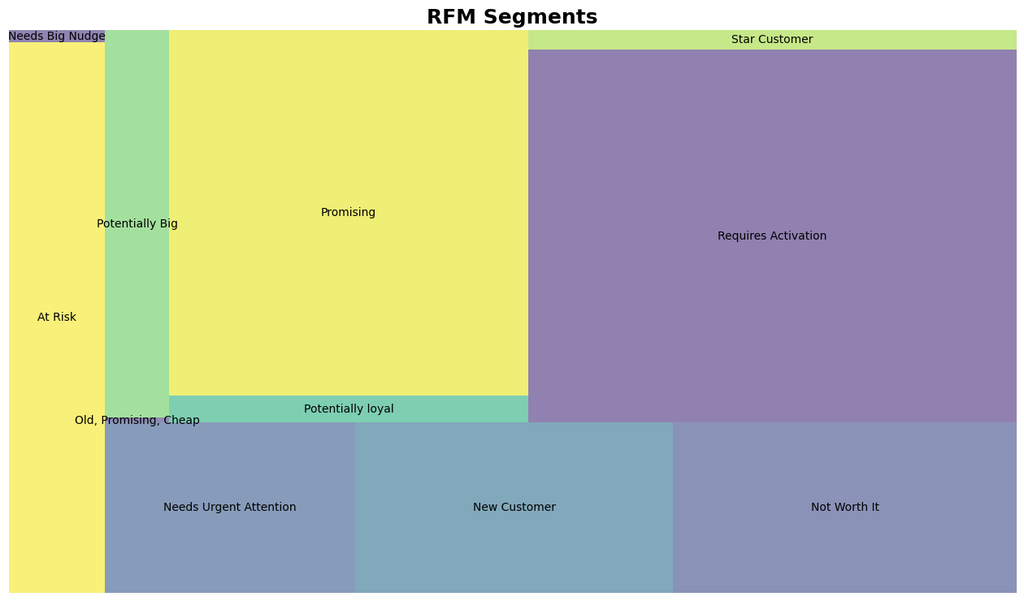

```python
rfm_level_agg.columns = rfm_level_agg.columns.droplevel()
rfm_level_agg.columns = ['RecencyMean','FrequencyMean','MonetaryMean', 'count']
#Create our plot and resize it.
fig = plt.gcf()
ax = fig.add_subplot()
fig.set_size_inches(16, 9)
squarify.plot(sizes=rfm_level_agg['count'],
              label=["At Risk",
                    "Needs Big Nudge",
                    "Needs Urgent Attention",
                    "New Customer",
                    "Not Worth It",
                    "Old, Promising, Cheap",
                    "Potentially Big",
                    "Potentially loyal",
                    "Promising",
                    "Requires Activation",
                    "Star Customer"], alpha=.6 )
plt.title("RFM Segments",fontsize=18,fontweight="bold")
plt.axis('off')
plt.show()
```

Trying Collaborative Filtering

```python
ecom_customer.head()
```

|  | id | Recency | Frequency | Monetary | Time on File | Category | Count | Sales |
| --- | --- | --- | --- | --- | --- | --- | --- | --- |
| 0 | 914 | 194 | 7 | 318.894775 | 1703 | fiction | 1 | 5.949997 |
| 1 | 957 | 3 | 14 | 368.052246 | 2364 | fiction | 1 | 12.680038 |
| 8 | 2801 | 96 | 9 | 164.324341 | 2453 | fiction | 1 | 0.000000 |
| 15 | 6157 | 75 | 7 | 220.850098 | 437 | fiction | 1 | 3.949999 |
| 17 | 6882 | 342 | 25 | 603.537109 | 2368 | fiction | 2 | 23.287613 |

```python
ecom_customer['R'] = np.searchsorted(m_bins, ecom_customer['Count'].values)
ecom_customer.head()
```

|  | id | Recency | Frequency | Monetary | Time on File | Category | Count | Sales | R |
| --- | --- | --- | --- | --- | --- | --- | --- | --- | --- |
| 0 | 914 | 194 | 7 | 318.894775 | 1703 | fiction | 1 | 5.949997 | 1 |
| 1 | 957 | 3 | 14 | 368.052246 | 2364 | fiction | 1 | 12.680038 | 1 |
| 8 | 2801 | 96 | 9 | 164.324341 | 2453 | fiction | 1 | 0.000000 | 1 |
| 15 | 6157 | 75 | 7 | 220.850098 | 437 | fiction | 1 | 3.949999 | 1 |
| 17 | 6882 | 342 | 25 | 603.537109 | 2368 | fiction | 2 | 23.287613 | 1 |

```python
def pct_rank_qcut(series, n):
    edges = pd.Series([float(i) / n for i in range(n + 1)])
    f = lambda x: (edges >= x).values.argmax()
    return series.rank(pct=1).apply(f)
```

```python
df = ecom_customer
df.head()
```

|  | id | Recency | Frequency | Monetary | Time on File | Category | Count | Sales | R |
| --- | --- | --- | --- | --- | --- | --- | --- | --- | --- |
| 0 | 914 | 194 | 7 | 318.894775 | 1703 | fiction | 1 | 5.949997 | 1 |
| 1 | 957 | 3 | 14 | 368.052246 | 2364 | fiction | 1 | 12.680038 | 1 |
| 8 | 2801 | 96 | 9 | 164.324341 | 2453 | fiction | 1 | 0.000000 | 1 |
| 15 | 6157 | 75 | 7 | 220.850098 | 437 | fiction | 1 | 3.949999 | 1 |
| 17 | 6882 | 342 | 25 | 603.537109 | 2368 | fiction | 2 | 23.287613 | 1 |

```python
# Rank the count on a scale of 5 across each category for every user.
ecom_customer['C'] = pct_rank_qcut(ecom_customer['Count'], 5)
ecom_customer.head()
```

|  | id | Recency | Frequency | Monetary | Time on File | Category | Count | Sales | R | C |
| --- | --- | --- | --- | --- | --- | --- | --- | --- | --- | --- |
| 0 | 914 | 194 | 7 | 318.894775 | 1703 | fiction | 1 | 5.949997 | 1 | 2 |
| 1 | 957 | 3 | 14 | 368.052246 | 2364 | fiction | 1 | 12.680038 | 1 | 2 |
| 8 | 2801 | 96 | 9 | 164.324341 | 2453 | fiction | 1 | 0.000000 | 1 | 2 |
| 15 | 6157 | 75 | 7 | 220.850098 | 437 | fiction | 1 | 3.949999 | 1 | 2 |
| 17 | 6882 | 342 | 25 | 603.537109 | 2368 | fiction | 2 | 23.287613 | 1 | 4 |

```python
# Create user-item matrix
user_matrix = ecom_customer.pivot_table(index='id', columns='Category', values='C')
user_matrix.head()
```

| Category id | GamesRiddles | art | cartoons | classics | compsci | conthist | cooking | economy | encyclopaedia | facsimile | ... | nonbooks | philosophy | politics | psychology | railroads | religion | science | sports | travelguides | videos |
| --- | --- | --- | --- | --- | --- | --- | --- | --- | --- | --- | --- | --- | --- | --- | --- | --- | --- | --- | --- | --- | --- |
| 914 | NaN | 2.0 | 2.0 | NaN | NaN | 5.0 | 2.0 | NaN | NaN | NaN | ... | NaN | NaN | NaN | NaN | NaN | NaN | NaN | NaN | 4.0 | NaN |
| 957 | NaN | NaN | 4.0 | NaN | 2.0 | 5.0 | NaN | NaN | 2.0 | NaN | ... | NaN | NaN | NaN | NaN | NaN | NaN | NaN | NaN | NaN | NaN |
| 1406 | NaN | NaN | NaN | NaN | NaN | 5.0 | NaN | NaN | NaN | NaN | ... | NaN | NaN | NaN | NaN | NaN | NaN | NaN | NaN | NaN | NaN |
| 1414 | NaN | NaN | NaN | NaN | NaN | 5.0 | NaN | NaN | NaN | NaN | ... | NaN | NaN | NaN | NaN | NaN | NaN | NaN | NaN | NaN | NaN |
| 1546 | NaN | 2.0 | 2.0 | NaN | NaN | 5.0 | NaN | 2.0 | NaN | NaN | ... | NaN | 4.0 | NaN | NaN | 4.0 | 2.0 | 4.0 | NaN | 2.0 | 4.0 |

5 rows × 30 columns

```python
# Normalize user-item matrix
user_matrix_norm = user_matrix.subtract(user_matrix.mean(axis=1), axis = 'rows')
user_matrix_norm.head()
```

| Category id | GamesRiddles | art | cartoons | classics | compsci | conthist | cooking | economy | encyclopaedia | facsimile | ... | nonbooks | philosophy | politics | psychology | railroads | religion | science | sports | travelguides | videos |
| --- | --- | --- | --- | --- | --- | --- | --- | --- | --- | --- | --- | --- | --- | --- | --- | --- | --- | --- | --- | --- | --- |
| 914 | NaN | -1.250 | -1.250 | NaN | NaN | 1.750 | -1.25 | NaN | NaN | NaN | ... | NaN | NaN | NaN | NaN | NaN | NaN | NaN | NaN | 0.750 | NaN |
| 957 | NaN | NaN | 0.000 | NaN | -2.0 | 1.000 | NaN | NaN | -2.0 | NaN | ... | NaN | NaN | NaN | NaN | NaN | NaN | NaN | NaN | NaN | NaN |
| 1406 | NaN | NaN | NaN | NaN | NaN | 1.500 | NaN | NaN | NaN | NaN | ... | NaN | NaN | NaN | NaN | NaN | NaN | NaN | NaN | NaN | NaN |
| 1414 | NaN | NaN | NaN | NaN | NaN | 0.000 | NaN | NaN | NaN | NaN | ... | NaN | NaN | NaN | NaN | NaN | NaN | NaN | NaN | NaN | NaN |
| 1546 | NaN | -1.375 | -1.375 | NaN | NaN | 1.625 | NaN | -1.375 | NaN | NaN | ... | NaN | 0.625 | NaN | NaN | 0.625 | -1.375 | 0.625 | NaN | -1.375 | 0.625 |

5 rows × 30 columns

```python
# User similarity matrix using Pearson correlation
user_similarity = user_matrix_norm.T.corr()
user_similarity.head()
```

| id | 914 | 957 | 1406 | 1414 | 1546 | 1651 | 2046 | 2062 | 2534 | 2623 | ... | 16228375 | 16252047 | 16252071 | 16252080 | 16252128 | 16252152 | 16252349 | 16252608 | 16252624 | 16252640 |
| --- | --- | --- | --- | --- | --- | --- | --- | --- | --- | --- | --- | --- | --- | --- | --- | --- | --- | --- | --- | --- | --- |
| 914 | 1.000000 | 0.809155 | NaN | NaN | 0.807645 | NaN | NaN | -0.407590 | 0.500000 | 0.842701 | ... | NaN | NaN | NaN | NaN | NaN | NaN | NaN | NaN | NaN | NaN |
| 957 | 0.809155 | 1.000000 | NaN | NaN | 0.881917 | NaN | 1.0 | -0.070221 | NaN | 0.834837 | ... | NaN | NaN | NaN | NaN | NaN | NaN | NaN | NaN | NaN | NaN |
| 1406 | NaN | NaN | 1.0 | NaN | NaN | -1.0 | NaN | NaN | NaN | NaN | ... | NaN | NaN | NaN | NaN | NaN | NaN | NaN | NaN | NaN | NaN |
| 1414 | NaN | NaN | NaN | NaN | NaN | NaN | NaN | NaN | NaN | NaN | ... | NaN | NaN | NaN | NaN | NaN | NaN | NaN | NaN | NaN | NaN |
| 1546 | 0.807645 | 0.881917 | NaN | NaN | 1.000000 | NaN | NaN | -0.415316 | 0.755929 | 0.675725 | ... | NaN | NaN | NaN | NaN | NaN | NaN | NaN | NaN | NaN | NaN |

5 rows × 32473 columns

```python
# Pick a user ID
picked_userid = 914
# Remove picked user ID from the candidate list
user_similarity.drop(index=picked_userid, inplace=True)
# Take a look at the data
user_similarity.head()
```

| id | 914 | 957 | 1406 | 1414 | 1546 | 1651 | 2046 | 2062 | 2534 | 2623 | ... | 16228375 | 16252047 | 16252071 | 16252080 | 16252128 | 16252152 | 16252349 | 16252608 | 16252624 | 16252640 |
| --- | --- | --- | --- | --- | --- | --- | --- | --- | --- | --- | --- | --- | --- | --- | --- | --- | --- | --- | --- | --- | --- |
| 957 | 0.809155 | 1.000000 | NaN | NaN | 0.881917 | NaN | 1.0 | -0.070221 | NaN | 0.834837 | ... | NaN | NaN | NaN | NaN | NaN | NaN | NaN | NaN | NaN | NaN |
| 1406 | NaN | NaN | 1.0 | NaN | NaN | -1.0 | NaN | NaN | NaN | NaN | ... | NaN | NaN | NaN | NaN | NaN | NaN | NaN | NaN | NaN | NaN |
| 1414 | NaN | NaN | NaN | NaN | NaN | NaN | NaN | NaN | NaN | NaN | ... | NaN | NaN | NaN | NaN | NaN | NaN | NaN | NaN | NaN | NaN |
| 1546 | 0.807645 | 0.881917 | NaN | NaN | 1.000000 | NaN | NaN | -0.415316 | 0.755929 | 0.675725 | ... | NaN | NaN | NaN | NaN | NaN | NaN | NaN | NaN | NaN | NaN |
| 1651 | NaN | NaN | -1.0 | NaN | NaN | 1.0 | NaN | -1.000000 | NaN | NaN | ... | NaN | NaN | NaN | NaN | NaN | NaN | NaN | NaN | NaN | NaN |

5 rows × 32473 columns

```python
# Number of similar users
n = 10
# User similarity threashold
user_similarity_threshold = 0.3
# Get top n similar users
similar_users = user_similarity[user_similarity[picked_userid]>user_similarity_threshold][picked_userid].sort_values(ascending=False)[:n]
# Print out top n similar users
print(f'The similar users for user {picked_userid} are', similar_users)
```

```
The similar users for user 914 are id
9278079    1.0
4090462    1.0
8723206    1.0
8722773    1.0
8722749    1.0
8721734    1.0
4074610    1.0
8721661    1.0
8721327    1.0
8719942    1.0
Name: 914, dtype: float64
```

```python
# Items that the target user has bought
picked_userid_watched = user_matrix_norm[user_matrix_norm.index == picked_userid].dropna(axis=1, how='all')
picked_userid_watched
```

| Category id | art | cartoons | conthist | cooking | fiction | health | music | travelguides |
| --- | --- | --- | --- | --- | --- | --- | --- | --- |
| 914 | -1.25 | -1.25 | 1.75 | -1.25 | -1.25 | 0.75 | 1.75 | 0.75 |

```python
# Items that similar users bought. Remove items that none of the similar users have bought
similar_user_items = user_matrix_norm[user_matrix_norm.index.isin(similar_users.index)].dropna(axis=1, how='all')
similar_user_items
```

| Category id | art | cartoons | compsci | conthist | cooking | encyclopaedia | health | history | hobby | learning | legends | linguistics | maps | music | nature | nonbooks | religion | science | travelguides | videos |
| --- | --- | --- | --- | --- | --- | --- | --- | --- | --- | --- | --- | --- | --- | --- | --- | --- | --- | --- | --- | --- |
| 4074610 | NaN | NaN | NaN | NaN | NaN | NaN | -2.0 | NaN | NaN | 1.0 | NaN | NaN | NaN | 1.000000 | NaN | NaN | NaN | NaN | NaN | NaN |
| 4090462 | NaN | NaN | 0.5 | NaN | NaN | -1.500000 | NaN | -1.500000 | 1.500000 | NaN | 0.500000 | NaN | -1.5 | 1.500000 | NaN | NaN | NaN | NaN | 0.5 | NaN |
| 8719942 | NaN | NaN | NaN | NaN | -1.2 | NaN | 1.8 | NaN | NaN | NaN | NaN | NaN | NaN | NaN | NaN | -1.200000 | -1.200000 | NaN | 1.8 | NaN |
| 8721327 | -1.000000 | NaN | NaN | NaN | NaN | NaN | NaN | NaN | NaN | NaN | NaN | NaN | NaN | 2.000000 | NaN | -1.000000 | NaN | NaN | NaN | NaN |
| 8721661 | NaN | NaN | -0.8 | NaN | NaN | NaN | -0.8 | 1.200000 | NaN | NaN | NaN | NaN | NaN | 1.200000 | NaN | -0.800000 | NaN | NaN | NaN | NaN |
| 8721734 | -0.666667 | NaN | NaN | 1.333333 | NaN | NaN | NaN | NaN | NaN | NaN | NaN | NaN | NaN | NaN | NaN | -0.666667 | NaN | NaN | NaN | NaN |
| 8722749 | NaN | -0.333333 | NaN | 1.666667 | NaN | -0.333333 | NaN | -0.333333 | NaN | NaN | -0.333333 | -0.333333 | NaN | NaN | NaN | NaN | NaN | NaN | NaN | NaN |
| 8722773 | NaN | -1.000000 | NaN | NaN | NaN | NaN | 1.0 | NaN | NaN | 1.0 | NaN | NaN | NaN | NaN | NaN | -1.000000 | NaN | NaN | NaN | NaN |
| 8723206 | NaN | 0.666667 | NaN | NaN | NaN | 0.666667 | NaN | NaN | -1.333333 | NaN | NaN | NaN | NaN | 1.666667 | -1.333333 | -1.333333 | -1.333333 | 0.666667 | NaN | 1.666667 |
| 9278079 | -0.666667 | NaN | NaN | NaN | NaN | NaN | NaN | NaN | NaN | NaN | NaN | NaN | NaN | 1.333333 | NaN | -0.666667 | NaN | NaN | NaN | NaN |

```python
# Remove the item bought by the picked user
similar_user_items.drop(picked_userid_watched.columns,axis=1, inplace=True, errors='ignore')
# Take a look at the data
similar_user_items
```

| Category id | compsci | encyclopaedia | history | hobby | learning | legends | linguistics | maps | nature | nonbooks | religion | science | videos |
| --- | --- | --- | --- | --- | --- | --- | --- | --- | --- | --- | --- | --- | --- |
| 4074610 | NaN | NaN | NaN | NaN | 1.0 | NaN | NaN | NaN | NaN | NaN | NaN | NaN | NaN |
| 4090462 | 0.5 | -1.500000 | -1.500000 | 1.500000 | NaN | 0.500000 | NaN | -1.5 | NaN | NaN | NaN | NaN | NaN |
| 8719942 | NaN | NaN | NaN | NaN | NaN | NaN | NaN | NaN | NaN | -1.200000 | -1.200000 | NaN | NaN |
| 8721327 | NaN | NaN | NaN | NaN | NaN | NaN | NaN | NaN | NaN | -1.000000 | NaN | NaN | NaN |
| 8721661 | -0.8 | NaN | 1.200000 | NaN | NaN | NaN | NaN | NaN | NaN | -0.800000 | NaN | NaN | NaN |
| 8721734 | NaN | NaN | NaN | NaN | NaN | NaN | NaN | NaN | NaN | -0.666667 | NaN | NaN | NaN |
| 8722749 | NaN | -0.333333 | -0.333333 | NaN | NaN | -0.333333 | -0.333333 | NaN | NaN | NaN | NaN | NaN | NaN |
| 8722773 | NaN | NaN | NaN | NaN | 1.0 | NaN | NaN | NaN | NaN | -1.000000 | NaN | NaN | NaN |
| 8723206 | NaN | 0.666667 | NaN | -1.333333 | NaN | NaN | NaN | NaN | -1.333333 | -1.333333 | -1.333333 | 0.666667 | 1.666667 |
| 9278079 | NaN | NaN | NaN | NaN | NaN | NaN | NaN | NaN | NaN | -0.666667 | NaN | NaN | NaN |

```python
#Recommend items to the user based on above
# A dictionary to store item scores
item_score = {}
# Loop through items
for i in similar_user_items.columns:
  # Get the ratings for item i
  item_rating = similar_user_items[i]
  # Create a variable to store the score
  total = 0
  # Create a variable to store the number of scores
  count = 0
  # Loop through similar users
  for u in similar_users.index:
    # If the item has rating
    if pd.isna(item_rating[u]) == False:
      # Score is the sum of user similarity score multiply by the item rating
      score = similar_users[u] * item_rating[u]
      # Add the score to the total score for the item so far
      total += score
      # Add 1 to the count
      count +=1
  # Get the average score for the item
  item_score[i] = total / count
# Convert dictionary to pandas dataframe
item_score = pd.DataFrame(item_score.items(), columns=['item', 'item_score'])

# Sort the items by score
ranked_item_score = item_score.sort_values(by='item_score', ascending=False)
# Select top m items
m = 10
ranked_item_score.head(m)
```

|  | item | item_score |
| --- | --- | --- |
| 12 | videos | 1.666667 |
| 4 | learning | 1.000000 |
| 11 | science | 0.666667 |
| 3 | hobby | 0.083333 |
| 5 | legends | 0.083333 |
| 0 | compsci | -0.150000 |
| 2 | history | -0.211111 |
| 6 | linguistics | -0.333333 |
| 1 | encyclopaedia | -0.388889 |
| 9 | nonbooks | -0.952381 |

Feed Dummy Data

```python
import random
recency_list = random.sample(range(ecom["Recency"].min(),ecom["Recency"].max()),100)
frequency_list = random.sample(range(0,100),100)
monetary_list = random.sample(range(int(ecom["Monetary"].min()),2000),100)
df_test = pd.DataFrame({'Recency':recency_list,'Frequency':frequency_list,'Monetary':monetary_list})
df_test.head()
```

|  | Recency | Frequency | Monetary |
| --- | --- | --- | --- |
| 0 | 1731 | 78 | 613 |
| 1 | 695 | 10 | 1466 |
| 2 | 116 | 45 | 515 |
| 3 | 1962 | 71 | 1476 |
| 4 | 930 | 22 | 700 |

```python
def RFM(df):
    df['R'] = np.searchsorted(m_bins, df['Recency'].values)
    df['F'] = np.searchsorted(m_bins, df['Frequency'].values)
    df['M'] = np.searchsorted(m_bins, df['Monetary'].values)
    df['R'] = df['R'].replace(4,3)
    df['F'] = df['F'].replace(5,4)
    df['M'] = df['M'].replace(4,3)
    df['RFM_Segment_Concat'] = df.apply(join_rfm, axis=1)
    rfm = df
    rfm['RFM_Level'] = rfm.apply(rfm_labels, axis=1)
    return rfm
```

```python
ecom_test = RFM(df_test)
ecom_test.head()
```

|  | Recency | Frequency | Monetary | R | F | M | RFM_Segment_Concat | RFM_Level |
| --- | --- | --- | --- | --- | --- | --- | --- | --- |
| 0 | 1731 | 78 | 613 | 3 | 2 | 3 | 323 | Needs Urgent Attention |
| 1 | 695 | 10 | 1466 | 3 | 1 | 3 | 313 | Needs Urgent Attention |
| 2 | 116 | 45 | 515 | 2 | 2 | 3 | 223 | Needs Big Nudge |
| 3 | 1962 | 71 | 1476 | 3 | 2 | 3 | 323 | Needs Urgent Attention |
| 4 | 930 | 22 | 700 | 3 | 1 | 3 | 313 | Needs Urgent Attention |

```python
ecom_f = rfm.append(ecom_test)
ecom_f.head()
```

|  | id | Recency | Frequency | Monetary | R | F | M | RFM_Segment_Concat | RFM_Level |
| --- | --- | --- | --- | --- | --- | --- | --- | --- | --- |
| 0 | 914.0 | 194 | 7 | 318.894775 | 2 | 3 | 3 | 233 | At Risk |
| 1 | 957.0 | 3 | 14 | 368.052246 | 1 | 4 | 3 | 143 | Star Customer |
| 2 | 1406.0 | 1489 | 15 | 423.298340 | 3 | 4 | 3 | 343 | Needs Urgent Attention |
| 3 | 1414.0 | 155 | 4 | 71.217041 | 2 | 3 | 2 | 232 | Promising |
| 4 | 1546.0 | 194 | 6 | 442.638184 | 2 | 3 | 3 | 233 | At Risk |

```python
# Calculate average values for each RFM_Level, and return a size of each segment
rfm_level_agg = ecom_f.groupby('RFM_Level').agg({
    'Recency': 'mean',
    'Frequency': 'mean',
    'Monetary': ['mean', 'count']
}).round(1)
# Print the aggregated dataset
rfm_level_agg
```

| RFM_Level | Recency mean | Frequency mean | Monetary mean | Monetary count |
| --- | --- | --- | --- | --- |
| At Risk | 137.4 | 14.3 | 569.7 | 3072 |
| Needs Big Nudge | 151.0 | 9.2 | 488.9 | 75 |
| Needs Urgent Attention | 728.8 | 11.5 | 537.9 | 2535 |
| New Customer | 135.7 | 1.1 | 14.1 | 3143 |
| Not Worth It | 865.1 | 1.3 | 16.5 | 3389 |
| Nudge, Loyal, Whale | 73.0 | 0.0 | 867.0 | 1 |
| Old, Promising, Cheap | 587.5 | 4.1 | 23.4 | 17 |
| Potentially Big | 17.0 | 7.8 | 248.8 | 1444 |
| Potentially loyal | 17.7 | 2.7 | 102.1 | 562 |
| Promising | 147.1 | 4.7 | 123.0 | 7592 |
| Requires Activation | 906.8 | 3.8 | 113.4 | 10553 |
| Star Customer | 16.5 | 20.6 | 695.7 | 548 |

[figure not shown]

```python
rfm_level_agg.columns = rfm_level_agg.columns.droplevel()
rfm_level_agg.columns = ['RecencyMean','FrequencyMean','MonetaryMean', 'count']
#Create our plot and resize it.
fig = plt.gcf()
ax = fig.add_subplot()
fig.set_size_inches(16, 9)
squarify.plot(sizes=rfm_level_agg['count'],
              label=["At Risk",
                    "Needs Big Nudge",
                    "Needs Urgent Attention",
                    "New Customer",
                    "Not Worth It",
                    "Old, Promising, Cheap",
                    "Potentially Big",
                    "Potentially loyal",
                    "Promising",
                    "Requires Activation",
                    "Star Customer"], alpha=.6 )
plt.title("RFM Segments",fontsize=18,fontweight="bold")
plt.axis('off')
plt.show()
```

# Old code

```python
# --Calculate R, F and M groups--
# Create labels for Recency and Frequency
r_labels = range(4, 0, -1); f_labels = range(1, 5); m_labels = range(1, 5)
# Assign these labels to 4 equal percentile groups
r_groups = pd.qcut(ecom_rfm['Recency'], q=4, labels=r_labels)
# Assign these labels to 4 equal percentile groups
f_groups = pd.qcut(ecom_rfm['Frequency'], q=4, labels=f_labels)
# Create new columns R and F
ecom_rfm_cal = ecom_rfm.assign(R = r_groups.values, F = f_groups.values)
# Create labels for MonetaryValue
# Assign these labels to three equal percentile groups
m_groups = pd.qcut(ecom_rfm['Monetary'], q=4, labels=m_labels)
# Create new column M
ecom_rfm_cal = ecom_rfm_cal.assign(M = m_groups.values)
```

```python
# Concat RFM quartile values to create RFM Segments
def join_rfm(x): return str(int(x['R'])) + str(int(x['F'])) + str(int(x['M']))
ecom_rfm_cal['RFM_Segment_Concat'] = ecom_rfm_cal.apply(join_rfm, axis=1)
```

```python
ecom_rfm_cal.head()
```

|  | Recency | Frequency | Monetary | Time on File | R | F | M | RFM_Segment_Concat |
| --- | --- | --- | --- | --- | --- | --- | --- | --- |
| 0 | 194 | 7 | 318.894775 | 1703 | 3 | 3 | 4 | 334 |
| 1 | 3 | 14 | 368.052246 | 2364 | 4 | 4 | 4 | 444 |
| 2 | 1489 | 15 | 423.298340 | 2371 | 1 | 4 | 4 | 144 |
| 3 | 155 | 4 | 71.217041 | 1290 | 3 | 3 | 2 | 332 |
| 4 | 194 | 6 | 442.638184 | 2188 | 3 | 3 | 4 | 334 |

```python
# Count num of unique segments
ecom_rfm_cal_count = ecom_rfm_cal.groupby('RFM_Segment_Concat')['RFM_Segment_Concat'].nunique()
ecom_rfm_cal_count.sum()
```

```
61
```

```python
# Calculate RFM_Score
ecom_rfm_cal['RFM_Score'] = ecom_rfm_cal[['R','F','M']].sum(axis=1)
ecom_rfm_cal.head(5)
```

|  | Recency | Frequency | Monetary | Time on File | R | F | M | RFM_Segment_Concat | RFM_Score |
| --- | --- | --- | --- | --- | --- | --- | --- | --- | --- |
| 0 | 194 | 7 | 318.894775 | 1703 | 3 | 3 | 4 | 334 | 10 |
| 1 | 3 | 14 | 368.052246 | 2364 | 4 | 4 | 4 | 444 | 12 |
| 2 | 1489 | 15 | 423.298340 | 2371 | 1 | 4 | 4 | 144 | 9 |
| 3 | 155 | 4 | 71.217041 | 1290 | 3 | 3 | 2 | 332 | 8 |
| 4 | 194 | 6 | 442.638184 | 2188 | 3 | 3 | 4 | 334 | 10 |

```python
# Define rfm_level function
def rfm_level(df):
    if df['RFM_Score'] == 12:
        return 'Best Customers'
    elif ((df['RFM_Score'] >= 9) and (df['RFM_Score'] < 12)):
        return "Can't lose them"
    elif ((df['RFM_Score'] >= 8) and (df['RFM_Score'] < 9)):
        return 'Champions'
    elif ((df['RFM_Score'] >= 7) and (df['RFM_Score'] < 8)):
        return 'Loyal'
    elif ((df['RFM_Score'] >= 6) and (df['RFM_Score'] < 7)):
        return 'Potential'
    elif ((df['RFM_Score'] >= 5) and (df['RFM_Score'] < 6)):
        return 'Promising'
    elif ((df['RFM_Score'] >= 4) and (df['RFM_Score'] < 5)):
        return 'Needs Attention'
    else:
        return 'Require Activation'
# Create a new variable RFM_Level
ecom_rfm_cal['RFM_Level'] = ecom_rfm_cal.apply(rfm_level, axis=1)
# Print the header with top 5 rows to the console
ecom_rfm_cal.head()
```

|  | Recency | Frequency | Monetary | Time on File | R | F | M | RFM_Segment_Concat | RFM_Score | RFM_Level |
| --- | --- | --- | --- | --- | --- | --- | --- | --- | --- | --- |
| 0 | 194 | 7 | 318.894775 | 1703 | 3 | 3 | 4 | 334 | 10 | Can't lose them |
| 1 | 3 | 14 | 368.052246 | 2364 | 4 | 4 | 4 | 444 | 12 | Best Customers |
| 2 | 1489 | 15 | 423.298340 | 2371 | 1 | 4 | 4 | 144 | 9 | Can't lose them |
| 3 | 155 | 4 | 71.217041 | 1290 | 3 | 3 | 2 | 332 | 8 | Champions |
| 4 | 194 | 6 | 442.638184 | 2188 | 3 | 3 | 4 | 334 | 10 | Can't lose them |

```python
# Calculate average values for each RFM_Level, and return a size of each segment
rfm_level_agg = ecom_rfm_cal.groupby('RFM_Level').agg({
    'Recency': 'mean',
    'Frequency': 'mean',
    'Monetary': ['mean', 'count']
}).round(1)
# Print the aggregated dataset
rfm_level_agg
```

| RFM_Level | Recency mean | Frequency mean | Monetary mean | Monetary count |
| --- | --- | --- | --- | --- |
| Best Customers | 47.4 | 16.0 | 564.8 | 2425 |
| Can't lose them | 265.4 | 9.1 | 326.0 | 9496 |
| Champions | 436.6 | 4.5 | 161.7 | 3785 |
| Loyal | 575.4 | 3.4 | 111.1 | 3812 |
| Needs Attention | 821.2 | 1.2 | 29.6 | 2962 |
| Potential | 524.5 | 2.1 | 62.6 | 4450 |
| Promising | 678.2 | 1.6 | 43.8 | 4375 |
| Require Activation | 1344.7 | 1.0 | 18.6 | 1526 |

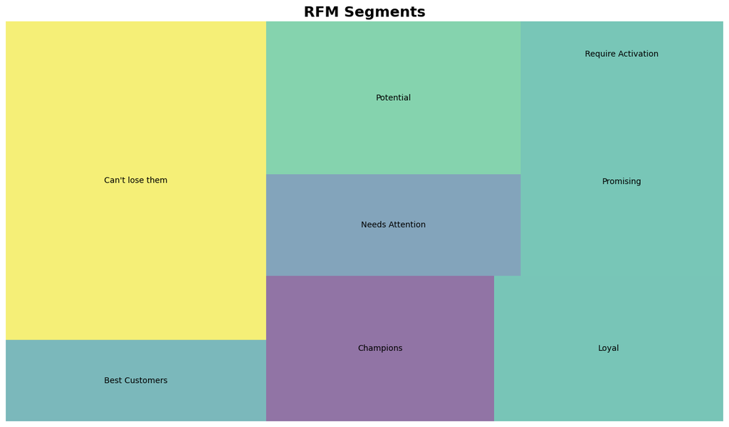

```python
rfm_level_agg.columns = rfm_level_agg.columns.droplevel()
rfm_level_agg.columns = ['RecencyMean','FrequencyMean','MonetaryMean', 'count']
#Create our plot and resize it.
fig = plt.gcf()
ax = fig.add_subplot()
fig.set_size_inches(16, 9)
squarify.plot(sizes=rfm_level_agg['count'],
              label=['Best Customers',
                     "Can't lose them",
                     'Champions',
                     'Loyal',
                     'Needs Attention',
                     'Potential',
                     'Promising',
                     'Require Activation'], alpha=.6 )
plt.title("RFM Segments",fontsize=18,fontweight="bold")
plt.axis('off')
plt.show()
```

#### Feed dummy data

```python
# Define function for RFM approach
def RFM(df):
    # --Calculate R, F and M groups--
    # Create labels for Recency and Frequency
    r_labels = range(4, 0, -1); f_labels = range(1, 5); m_labels = range(1, 5)
    # Assign these labels to 4 equal percentile groups
    r_groups = pd.qcut(df['Recency'], q=4, labels=r_labels)
    # Assign these labels to 4 equal percentile groups
    f_groups = pd.qcut(df['Frequency'], q=4, labels=f_labels)
    # Create new columns R and F
    df_process = df.assign(R = r_groups.values, F = f_groups.values)
    # Create labels for MonetaryValue
    # Assign these labels to three equal percentile groups
    m_groups = pd.qcut(df['Monetary'], q=4, labels=m_labels)
    # Create new column M
    df_process = df_process.assign(M = m_groups.values)
    rfm = df_process
    # Calculate RFM_Score
    rfm['RFM_Score'] = rfm[['R','F','M']].sum(axis=1)
    # Define rfm_level function
    # Create a new variable RFM_Level
    rfm['RFM_Level'] = rfm.apply(rfm_level, axis=1)
    return rfm
```

```python
import random
def rand_gen():
    rand_list=[]
    n=100
    for i in range(n):
        rand_list.append(random.randint(0,10000))
    return rand_list

r_rand = rand_gen()
f_rand = rand_gen()
m_rand = rand_gen()
ecom_test = pd.DataFrame({'Recency':r_rand,
                          'Frequency':f_rand,
                          'Monetary':m_rand})
ecom_test
```

|  | Recency | Frequency | Monetary |
| --- | --- | --- | --- |
| 0 | 2580 | 81 | 8975 |
| 1 | 3306 | 6203 | 2917 |
| 2 | 1720 | 6445 | 6164 |
| 3 | 2158 | 7788 | 8659 |
| 4 | 7549 | 3699 | 9942 |
| 5 | 1870 | 6443 | 5571 |
| 6 | 5011 | 350 | 3658 |
| 7 | 4251 | 2055 | 2340 |
| 8 | 7582 | 9418 | 1069 |
| 9 | 2764 | 2934 | 5057 |
| 10 | 4405 | 5322 | 6512 |
| 11 | 2201 | 7609 | 3823 |
| 12 | 1259 | 2265 | 5411 |
| 13 | 4722 | 9665 | 1488 |
| 14 | 4577 | 3674 | 2986 |
| 15 | 4054 | 2260 | 5982 |
| 16 | 837 | 5530 | 3963 |
| 17 | 6847 | 3594 | 9182 |
| 18 | 166 | 1885 | 3000 |
| 19 | 4548 | 9219 | 9492 |
| 20 | 2677 | 3372 | 6541 |
| 21 | 4941 | 5004 | 1299 |
| 22 | 4052 | 5226 | 4006 |
| 23 | 5153 | 8943 | 8359 |
| 24 | 5648 | 3996 | 7465 |
| 25 | 8078 | 2401 | 1186 |
| 26 | 9910 | 7573 | 1698 |
| 27 | 5759 | 3980 | 3860 |
| 28 | 9239 | 4900 | 1031 |
| 29 | 6618 | 2159 | 6231 |

[output cut: 70 more lines]

```python
ecom_test_cal = RFM(ecom_rfm[['Recency', 'Frequency', 'Monetary']].append(ecom_test))
ecom_test_cal.head()
```

|  | Recency | Frequency | Monetary | R | F | M | RFM_Score | RFM_Level |
| --- | --- | --- | --- | --- | --- | --- | --- | --- |
| 0 | 194 | 7 | 318.894775 | 3 | 3 | 4 | 10 | Can't lose them |
| 1 | 3 | 14 | 368.052246 | 4 | 4 | 4 | 12 | Best Customers |
| 2 | 1489 | 15 | 423.298340 | 1 | 4 | 4 | 9 | Can't lose them |
| 3 | 155 | 4 | 71.217041 | 3 | 3 | 2 | 8 | Champions |
| 4 | 194 | 6 | 442.638184 | 3 | 3 | 4 | 10 | Can't lose them |

```python
# Calculate average values for each RFM_Level, and return a size of each segment
rfm_level_agg = ecom_test_cal.groupby('RFM_Level').agg({
    'Recency': 'mean',
    'Frequency': 'mean',
    'Monetary': ['mean', 'count']
}).round(1)
# Print the aggregated dataset
rfm_level_agg
```

| RFM_Level | Recency mean | Frequency mean | Monetary mean | Monetary count |
| --- | --- | --- | --- | --- |
| Best Customers | 47.8 | 19.8 | 569.7 | 2422 |
| Can't lose them | 314.0 | 60.5 | 369.2 | 9586 |
| Champions | 437.0 | 7.2 | 161.6 | 3796 |
| Loyal | 576.6 | 4.3 | 111.0 | 3820 |
| Needs Attention | 822.4 | 1.2 | 29.7 | 2957 |
| Potential | 525.0 | 2.1 | 62.7 | 4451 |
| Promising | 677.5 | 1.6 | 43.8 | 4376 |
| Require Activation | 1351.2 | 1.0 | 18.8 | 1523 |

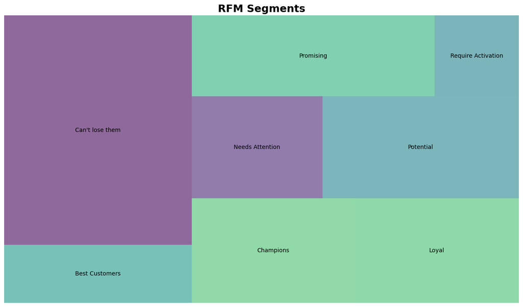

```python
rfm_level_agg.columns = rfm_level_agg.columns.droplevel()
rfm_level_agg.columns = ['RecencyMean','FrequencyMean','MonetaryMean', 'count']
#Create our plot and resize it.
fig = plt.gcf()
ax = fig.add_subplot()
fig.set_size_inches(16, 9)
squarify.plot(sizes=rfm_level_agg['count'],
              label=['Best Customers',
                     "Can't lose them",
                     'Champions',
                     'Loyal',
                     'Needs Attention',
                     'Potential',
                     'Promising',
                     'Require Activation'], alpha=.6 )
plt.title("RFM Segments",fontsize=18,fontweight="bold")
plt.axis('off')
plt.show()
```